# RNA-seq data processing using Salmon + DESeq2 pipeline

Ye Yuan

# Data description

LD data for CTR1 male mouse are downloaded from SRA archive.

```r
coldata <- read.csv("experiment_info_LD_CTR1_male.csv", row.names=1, stringsAsFactors=FALSE)
coldata
```

|  | zeitgeber_time | Bases | BioProject | BioSample | Experiment | GEO_Accession..exp. | sex | source_name | SRA.Study | strain |
| --- | --- | --- | --- | --- | --- | --- | --- | --- | --- | --- |
| SRR7161649 | ZT02 | 2457983268 | PRJNA471297 | SAMN04440684 | SRX4080514 | GSM2046155 | male | Liver Total RNA | SRP145606 | C57BL/6J |
| SRR7161650 | ZT02 | 2408935042 | PRJNA471297 | SAMN04440684 | SRX4080514 | GSM2046155 | male | Liver Total RNA | SRP145606 | C57BL/6J |
| SRR7161651 | ZT02 | 2398080976 | PRJNA471297 | SAMN04440684 | SRX4080514 | GSM2046155 | male | Liver Total RNA | SRP145606 | C57BL/6J |
| SRR7161652 | ZT02 | 2407413376 | PRJNA471297 | SAMN04440684 | SRX4080514 | GSM2046155 | male | Liver Total RNA | SRP145606 | C57BL/6J |
| SRR7161653 | ZT02 | 2428252302 | PRJNA471297 | SAMN04440684 | SRX4080514 | GSM2046155 | male | Liver Total RNA | SRP145606 | C57BL/6J |
| SRR7161654 | ZT02 | 2404337320 | PRJNA471297 | SAMN04440684 | SRX4080514 | GSM2046155 | male | Liver Total RNA | SRP145606 | C57BL/6J |
| SRR7161655 | ZT02 | 2403926048 | PRJNA471297 | SAMN04440684 | SRX4080514 | GSM2046155 | male | Liver Total RNA | SRP145606 | C57BL/6J |
| SRR7161656 | ZT02 | 2415574176 | PRJNA471297 | SAMN04440684 | SRX4080514 | GSM2046155 | male | Liver Total RNA | SRP145606 | C57BL/6J |
| SRR7161657 | ZT06 | 2172881478 | PRJNA471297 | SAMN04440685 | SRX4080515 | GSM2046156 | male | Liver Total RNA | SRP145606 | C57BL/6J |
| SRR7161658 | ZT06 | 2108081090 | PRJNA471297 | SAMN04440685 | SRX4080515 | GSM2046156 | male | Liver Total RNA | SRP145606 | C57BL/6J |

[output cut: 38 more lines]

# Data reading

First, we construct the tximeta object. Then, we convert tximeta objects into DESeq2 objects.

## tximeta construction

```r
quant_root <- "quant_GCbias"
coldata$names <- row.names(coldata)
dir_names <- paste(coldata$Experiment,row.names(coldata),"quant",sep="_")
coldata$files <- file.path(quant_root,dir_names,"quant.sf")
all(file.exists(coldata$files))
```

```
## [1] TRUE
```

```r
library("tximeta")
library(DESeq2)
se <- tximeta(coldata)
```

```
## importing quantifications
```

```
## reading in files with read_tsv
```

```
## 1 2 3 4 5 6 7 8 9 10 11 12 13 14 15 16 17 18 19 20 21 22 23 24 25 26 27 28 29 30 31 32 33 34 35 36 37 38 39 40 41 42 43 44 45 46 47 48
## found matching transcriptome:
## [ GENCODE - Mus musculus - release M23 ]
## loading existing TxDb created: 2020-04-03 22:45:22
## loading existing transcript ranges created: 2020-04-03 22:46:20
## fetching genome info for GENCODE
```

Convert from transcript level to gene level statistics

```r
gse <- summarizeToGene(se)
```

```
## loading existing TxDb created: 2020-04-03 22:45:22
```

```
## obtaining transcript-to-gene mapping from TxDb
```

```
## loading existing gene ranges created: 2020-04-03 22:49:51
```

```
## summarizing abundance
```

```
## summarizing counts
```

```
## summarizing length
```

```r
# Look at some statistics about the gse object:
#dim(gse) ; assayNames(gse) ; head(assay(gse), 1) ; colSums(assay(gse)) ; rowRanges(gse) ;
seqinfo(rowRanges(gse))
```

```
## Seqinfo object with 22 sequences (1 circular) from mm10 genome:
##   seqnames seqlengths isCircular genome
##   chr1      195471971      FALSE   mm10
##   chr2      182113224      FALSE   mm10
##   chr3      160039680      FALSE   mm10
##   chr4      156508116      FALSE   mm10
##   chr5      151834684      FALSE   mm10
##   ...             ...        ...    ...
##   chr18      90702639      FALSE   mm10
##   chr19      61431566      FALSE   mm10
##   chrX      171031299      FALSE   mm10
##   chrY       91744698      FALSE   mm10
##   chrM          16299       TRUE   mm10
```

```r
# Finally, check whether experiment metadata is imported correctly:
colData(gse)
```

```
## DataFrame with 48 rows and 11 columns
##            zeitgeber_time      Bases  BioProject    BioSample  Experiment
##               <character>  <numeric> <character>  <character> <character>
## SRR7161649           ZT02 2457983268 PRJNA471297 SAMN04440684  SRX4080514
## SRR7161650           ZT02 2408935042 PRJNA471297 SAMN04440684  SRX4080514
## SRR7161651           ZT02 2398080976 PRJNA471297 SAMN04440684  SRX4080514
## SRR7161652           ZT02 2407413376 PRJNA471297 SAMN04440684  SRX4080514
## SRR7161653           ZT02 2428252302 PRJNA471297 SAMN04440684  SRX4080514
## ...                   ...        ...         ...          ...         ...
## SRR7161692           ZT22 2117081806 PRJNA471297 SAMN04440687  SRX4080519
## SRR7161693           ZT22 2106127144 PRJNA471297 SAMN04440687  SRX4080519
## SRR7161694           ZT22 2158656032 PRJNA471297 SAMN04440687  SRX4080519
## SRR7161695           ZT22 2118293806 PRJNA471297 SAMN04440687  SRX4080519
## SRR7161696           ZT22 2160254862 PRJNA471297 SAMN04440687  SRX4080519
##            GEO_Accession..exp.         sex     source_name   SRA.Study
##                    <character> <character>     <character> <character>
## SRR7161649          GSM2046155        male Liver Total RNA   SRP145606
## SRR7161650          GSM2046155        male Liver Total RNA   SRP145606
## SRR7161651          GSM2046155        male Liver Total RNA   SRP145606
## SRR7161652          GSM2046155        male Liver Total RNA   SRP145606
## SRR7161653          GSM2046155        male Liver Total RNA   SRP145606
## ...                        ...         ...             ...         ...
## SRR7161692          GSM2046160        male Liver Total RNA   SRP145606
## SRR7161693          GSM2046160        male Liver Total RNA   SRP145606
## SRR7161694          GSM2046160        male Liver Total RNA   SRP145606
## SRR7161695          GSM2046160        male Liver Total RNA   SRP145606
## SRR7161696          GSM2046160        male Liver Total RNA   SRP145606
##                 strain       names
##            <character> <character>
## SRR7161649    C57BL/6J  SRR7161649
## SRR7161650    C57BL/6J  SRR7161650
## SRR7161651    C57BL/6J  SRR7161651
## SRR7161652    C57BL/6J  SRR7161652
## SRR7161653    C57BL/6J  SRR7161653
## ...                ...         ...
## SRR7161692    C57BL/6J  SRR7161692
## SRR7161693    C57BL/6J  SRR7161693
## SRR7161694    C57BL/6J  SRR7161694
## SRR7161695    C57BL/6J  SRR7161695
## SRR7161696    C57BL/6J  SRR7161696
```

## DESeq2 import and filtering

Note - for the filtering criteria, I am not very sure.

Note - for VST parameter blind, I am not sure.

TODO - pheatmap output has partially overlapping column labels.

```r
gse$zt <- gse$zeitgeber_time
gse$zt <- as.factor(gse$zt)
head(colData(gse),3)
```

```
## DataFrame with 3 rows and 12 columns
##            zeitgeber_time      Bases  BioProject    BioSample  Experiment
##               <character>  <numeric> <character>  <character> <character>
## SRR7161649           ZT02 2457983268 PRJNA471297 SAMN04440684  SRX4080514
## SRR7161650           ZT02 2408935042 PRJNA471297 SAMN04440684  SRX4080514
## SRR7161651           ZT02 2398080976 PRJNA471297 SAMN04440684  SRX4080514
##            GEO_Accession..exp.         sex     source_name   SRA.Study
##                    <character> <character>     <character> <character>
## SRR7161649          GSM2046155        male Liver Total RNA   SRP145606
## SRR7161650          GSM2046155        male Liver Total RNA   SRP145606
## SRR7161651          GSM2046155        male Liver Total RNA   SRP145606
##                 strain       names       zt
##            <character> <character> <factor>
## SRR7161649    C57BL/6J  SRR7161649     ZT02
## SRR7161650    C57BL/6J  SRR7161650     ZT02
## SRR7161651    C57BL/6J  SRR7161651     ZT02
```

```r
dds <- DESeqDataSet(gse, design = ~ zt)
```

```
## using counts and average transcript lengths from tximeta
```

```r
paste("pre-fitering gene-level record count is", as.character(nrow(dds)))
```

```
## [1] "pre-fitering gene-level record count is 54281"
```

```r
keep <- rowSums(counts(dds)) > 1 #basic filter
#keep <- rowSums(counts(dds) >= 10) >= 3 #enhanced filter
dds <- dds[keep,]
paste("filtered gene-level record count is", as.character(nrow(dds)))
```

```
## [1] "filtered gene-level record count is 26395"
```

## VST transform and sample distances visualization

```r
vsd <- vst(dds,blind=FALSE)
```

```
## using 'avgTxLength' from assays(dds), correcting for library size
```

```r
vsd$zt
```

```
##  [1] ZT02 ZT02 ZT02 ZT02 ZT02 ZT02 ZT02 ZT02 ZT06 ZT06 ZT06 ZT06 ZT06 ZT06 ZT06
## [16] ZT06 ZT10 ZT10 ZT10 ZT10 ZT10 ZT10 ZT10 ZT10 ZT14 ZT14 ZT14 ZT14 ZT14 ZT14
## [31] ZT14 ZT14 ZT18 ZT18 ZT18 ZT18 ZT18 ZT18 ZT18 ZT18 ZT22 ZT22 ZT22 ZT22 ZT22
## [46] ZT22 ZT22 ZT22
## Levels: ZT02 ZT06 ZT10 ZT14 ZT18 ZT22
```

```r
sampleDists <- dist(t(assay(vsd))) #this returns a pairwise distance of the samples across all genes after filter.
```

Then, we visualize the distances.

First by heatmaps:

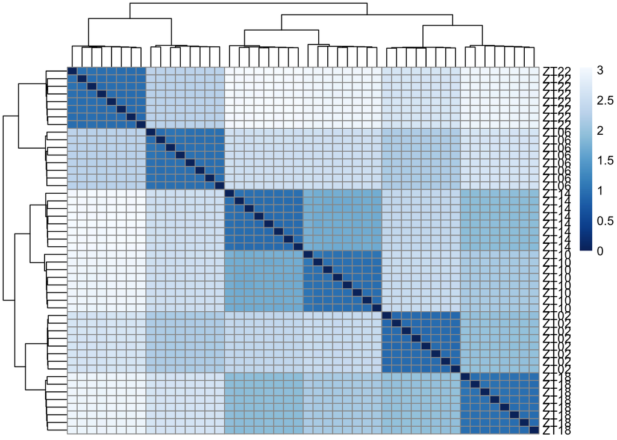

```r
library("pheatmap")
library("RColorBrewer")
sampleDistMatrix <- as.matrix(sampleDists)
rownames(sampleDistMatrix) <- vsd$zt
colnames(sampleDistMatrix) <- NULL
colors <- colorRampPalette(rev(brewer.pal(9, "Blues")) )(255)
#       clustered heatmap option
pheatmap(sampleDistMatrix,
         clustering_distance_rows = sampleDists,
         clustering_distance_cols = sampleDists, col = colors)
```

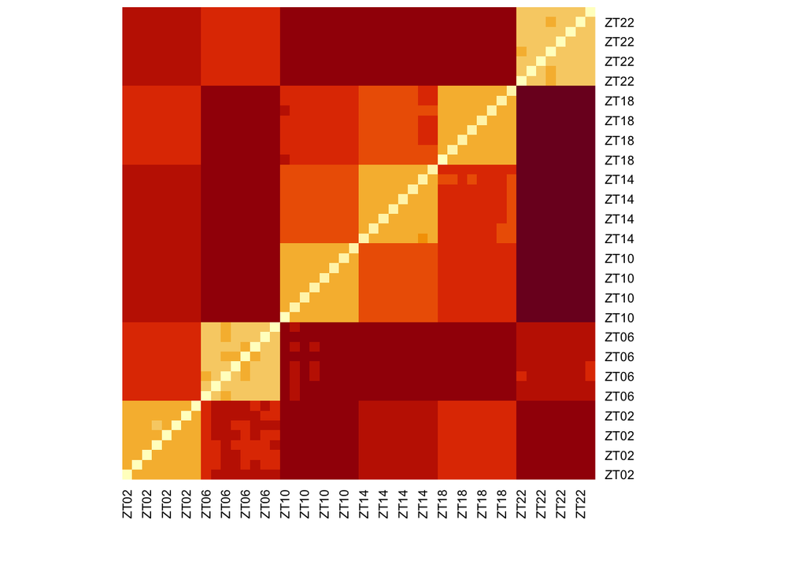

```r
#       ordinary heatmap option
colnames(sampleDistMatrix) <- vsd$zt
heatmap(sampleDistMatrix, Colv = NA, Rowv = NA)
```

Then by PCA:

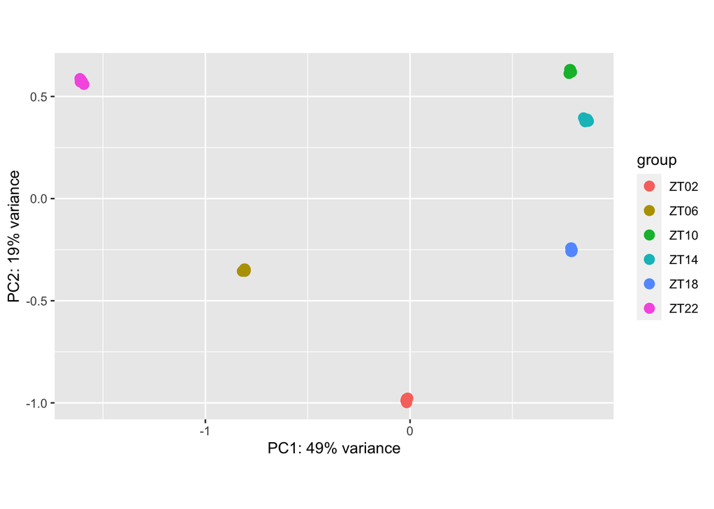

```r
plotPCA(vsd, intgroup = c("zt"))
```

# Differential expression analysis

Next use DESeq package to analyze DE.

```r
dds <- DESeq(dds)
```

```
## using 'avgTxLength' from assays(dds), correcting for library size
```

```
## -- replacing outliers and refitting for 16 genes
## -- DESeq argument 'minReplicatesForReplace' = 7
## -- original counts are preserved in counts(dds)
```

## p-value and adjusted p-value analysis

Also, note that DESeq automatically applies independent filtering based on baseMean column. Another way to do filtering is by independent hypothesis weighting.

First, p-value analysis:

```r
# a quick function for pretty output of p-value dataframe results
df_pretty <- function(df,order_column, decre = FALSE, head_count=5,fmt="e",dig=2){
        df_temp <- df
        df_temp$row_name <- row.names(df_temp)
        as.data.frame(lapply(head(df_temp[order(df_temp[[order_column]], decreasing=decre),],head_count),formatC, format=fmt, digits=dig))
}
```

```r
pvalue_threshold <- 0.05
res <- results(dds, contrast=c("zt","ZT22","ZT10"), alpha = pvalue_threshold) #Specify the contrast here
paste("genes with non-NA p-value result = ", as.character(sum(!is.na(res$pvalue))))
```

```
## [1] "genes with non-NA p-value result =  26395"
```

```r
#mcols(res, use.names = TRUE) #shows structure of the dataframe.
#summary(res)
resSig.pvalue <- subset(res, pvalue < pvalue_threshold)
paste("genes with p-value below threshold", as.character(length(resSig.pvalue$pvalue)))
```

```
## [1] "genes with p-value below threshold 7353"
```

```r
df_pretty(resSig.pvalue,"log2FoldChange")
```

| baseMean | log2FoldChange | lfcSE | stat | pvalue | padj | row_name |
| --- | --- | --- | --- | --- | --- | --- |
| 2.22e+01 | -2.37e+01 | 4.26e+00 | -5.56e+00 | 2.65e-08 | 2.31e-07 | ENSMUSG00000078087.5 |
| 2.98e+01 | -6.35e+00 | 5.11e-01 | -1.24e+01 | 1.49e-35 | 3.90e-34 | ENSMUSG00000038550.10 |
| 6.51e+01 | -4.72e+00 | 1.75e-01 | -2.70e+01 | 1.51e-160 | 1.31e-158 | ENSMUSG00000026475.7 |
| 4.92e+01 | -4.70e+00 | 2.80e-01 | -1.68e+01 | 4.56e-63 | 1.86e-61 | ENSMUSG00000021228.15 |
| 2.24e+02 | -4.69e+00 | 1.02e-01 | -4.59e+01 | 0.00e+00 | 0.00e+00 | ENSMUSG00000059824.12 |

```r
df_pretty(resSig.pvalue,"log2FoldChange",decre=TRUE)
```

| baseMean | log2FoldChange | lfcSE | stat | pvalue | padj | row_name |
| --- | --- | --- | --- | --- | --- | --- |
| 4.69e+03 | 8.70e+00 | 6.99e-02 | 1.24e+02 | 0.00e+00 | 0.00e+00 | ENSMUSG00000057465.5 |
| 4.23e+02 | 8.04e+00 | 1.76e-01 | 4.58e+01 | 0.00e+00 | 0.00e+00 | ENSMUSG00000026822.14 |
| 5.36e+03 | 7.23e+00 | 4.16e-02 | 1.74e+02 | 0.00e+00 | 0.00e+00 | ENSMUSG00000074115.5 |
| 5.99e+02 | 6.42e+00 | 9.32e-02 | 6.89e+01 | 0.00e+00 | 0.00e+00 | ENSMUSG00000061540.3 |
| 6.88e+00 | 5.91e+00 | 7.56e-01 | 7.81e+00 | 5.75e-15 | 7.78e-14 | ENSMUSG00000075014.1 |

Second, adjusted p-value analysis:

```r
padj_threshold <- 0.05
paste("genes with non-NA p-value result = ", as.character(sum(res$padj < padj_threshold, na.rm=TRUE)))
```

```
## [1] "genes with non-NA p-value result =  5907"
```

```r
resSig.padj <- subset(res, padj < padj_threshold)
paste("genes with p-value below threshold", as.character(length(resSig.padj$pvalue)))
```

```
## [1] "genes with p-value below threshold 5907"
```

```r
df_pretty(resSig.padj,"log2FoldChange")
```

| baseMean | log2FoldChange | lfcSE | stat | pvalue | padj | row_name |
| --- | --- | --- | --- | --- | --- | --- |
| 2.22e+01 | -2.37e+01 | 4.26e+00 | -5.56e+00 | 2.65e-08 | 2.31e-07 | ENSMUSG00000078087.5 |
| 2.98e+01 | -6.35e+00 | 5.11e-01 | -1.24e+01 | 1.49e-35 | 3.90e-34 | ENSMUSG00000038550.10 |
| 6.51e+01 | -4.72e+00 | 1.75e-01 | -2.70e+01 | 1.51e-160 | 1.31e-158 | ENSMUSG00000026475.7 |
| 4.92e+01 | -4.70e+00 | 2.80e-01 | -1.68e+01 | 4.56e-63 | 1.86e-61 | ENSMUSG00000021228.15 |
| 2.24e+02 | -4.69e+00 | 1.02e-01 | -4.59e+01 | 0.00e+00 | 0.00e+00 | ENSMUSG00000059824.12 |

```r
df_pretty(resSig.padj,"log2FoldChange",decre=TRUE)
```

| baseMean | log2FoldChange | lfcSE | stat | pvalue | padj | row_name |
| --- | --- | --- | --- | --- | --- | --- |
| 4.69e+03 | 8.70e+00 | 6.99e-02 | 1.24e+02 | 0.00e+00 | 0.00e+00 | ENSMUSG00000057465.5 |
| 4.23e+02 | 8.04e+00 | 1.76e-01 | 4.58e+01 | 0.00e+00 | 0.00e+00 | ENSMUSG00000026822.14 |
| 5.36e+03 | 7.23e+00 | 4.16e-02 | 1.74e+02 | 0.00e+00 | 0.00e+00 | ENSMUSG00000074115.5 |
| 5.99e+02 | 6.42e+00 | 9.32e-02 | 6.89e+01 | 0.00e+00 | 0.00e+00 | ENSMUSG00000061540.3 |
| 6.88e+00 | 5.91e+00 | 7.56e-01 | 7.81e+00 | 5.75e-15 | 7.78e-14 | ENSMUSG00000075014.1 |

## annotation of the results and exporting the list

It would be helpful to convert the Ensembl gene IDs to alternative gene names.

Note - many mapping between keys and columns!

```r
library("AnnotationDbi")
library("org.Mm.eg.db")
```

```r
ens.str <- substr(rownames(resSig.padj),1,18)
resSig.padj$symbol <- mapIds(org.Mm.eg.db, keys=ens.str,column="SYMBOL",
                     keytype="ENSEMBL", multiVals="first")
resSig.padj$entrez <- mapIds(org.Mm.eg.db, keys=ens.str,column="ENTREZID",
                     keytype="ENSEMBL", multiVals="first")
head(resSig.padj,1)
```

```
## log2 fold change (MLE): zt ZT22 vs ZT10
## Wald test p-value: zt ZT22 vs ZT10
## DataFrame with 1 row and 8 columns
##                               baseMean     log2FoldChange               lfcSE
##                              <numeric>          <numeric>           <numeric>
## ENSMUSG00000000049.11 8548.70163605888 0.0440609348576828 0.00894397428098846
##                                   stat               pvalue
##                              <numeric>            <numeric>
## ENSMUSG00000000049.11 4.92632620280895 8.37900714094142e-07
##                                       padj      symbol      entrez
##                                  <numeric> <character> <character>
## ENSMUSG00000000049.11 6.18537899406722e-06        Apoh       11818
```

Finally, divide the list into two categories (phase and antiphase) and export:

```r
resSig.padj.plus <- subset(resSig.padj, log2FoldChange > 0)
resSig.padj.minus <- subset(resSig.padj, log2FoldChange < 0)
write.csv(na.omit(as.data.frame(resSig.padj.plus)), file="phase_genes.csv")
write.csv(na.omit(as.data.frame(resSig.padj.minus)), file="antiphase_genes.csv")
```